# Coursework Report

*N* removed NAs: 3

*N* removed typo: 1

*N* removed <18: 17

*N* total clean: 129

| Group | *N* | *M*<sub>age</sub> | *M*<sub>rating</sub> |
| --- | --- | --- | --- |
| Control | 57 | 21.3 | 6.16 |
| Experim | 72 | 20.5 | 5.62 |

**Main analysis results**

*t*(127) = 3.86, *p* < .001

[interactive chart not shown]

[figure not shown]

[interactive chart not shown]

# Coursework Report

Analysing Data, Spring 2020

# Methods

## Participants

150 participants initially took part in this study. 17 participants were removed for ethical reasons, i.e. those that were under the age of 18. 1 participant was removed as their age ‘1q’ was ambiguous and a final 3 were removed due to non-existent data points. the final number of participants involved in the experiment was 129. The mean age of these participants was 20.86 (range 18 - 28) with a standard deviation of 2.15.

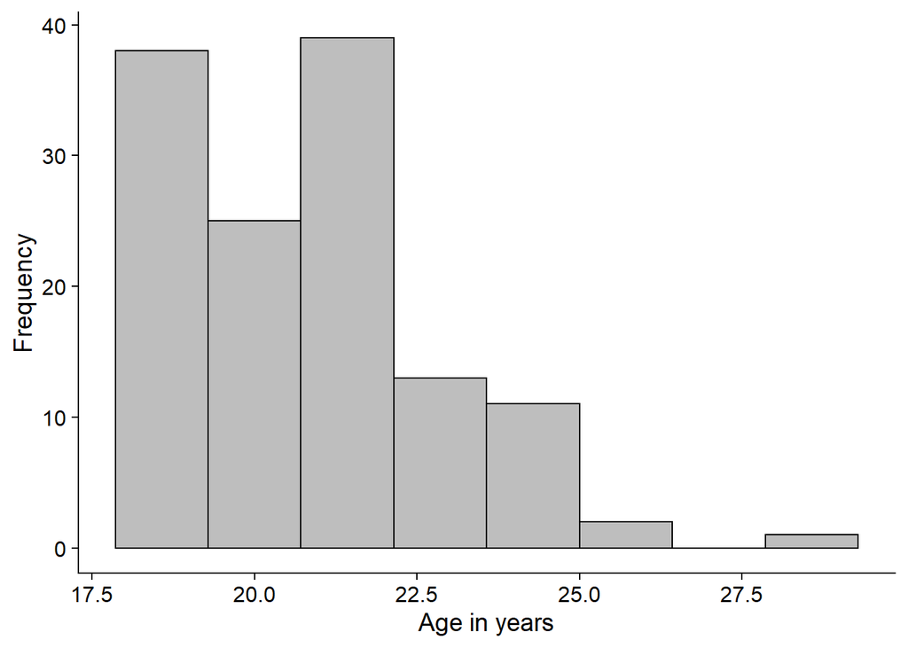

## Design

This experiment aims to test whether the background colour of a photo of a man, either white or red, would have an effect on the perceived attractiveness of that man. The participants were given a black and white photo of a man on either a red or white background and then responded to items on perceptions of attractiveness. Perceived attractiveness was measured using three items. These included; “how attractive do you think this person is?”, “how pleasant is this person to look at?” and “if i were to meet the person face-to-face, i would think he is attractive”. The items were measured using a rating scale between 1 (not attractive) to 9 (extremely attractive), therefore the higher the rating, the more attractive the participant periceived the man to be. A composite score was calculated for each participant, to give a single overall rating of attractiveness that took all items into account. The operational hypothesis for this experiment is that ratings on perceived attractiveness items will be higher for those in the red condition, compared to those in the white condition. A t-test will be carried out for the statistical analysis to measure significance.

# Results

Following on from the experiment, a composite score was calculated for each condition to give a single value of perceived attractiveness for each group. This was done by calculating the mean item rating score for each participant, then using these values to calculate an overall mean for the separate red and white conditions. The mean for the white (control) condition was 6.16 and the mean for the red condition was 5.62.

Mean Attractiveness Rating

| Colour Condition | *M*<sub>Attractiveness</sub> | *SD*<sub>Attractiveness</sub> |
| --- | --- | --- |
| control | 6.16 | 1.41 |
| experimental | 5.62 | 1.46 |

We then calculated an independant measures t-test. This analysis showed that there was a difference between the red and white conditions on perceived attractiveness (*M*<sub>diff</sub> = 0.55, 95% CI [0.27, 0.83]) and there was a significant difference between the two conditions on ratings of attractiveness (*t* (127) = 3.86, *p* = .0002). it is unlikely that we would find a value for t this big if there was no real difference between the means and the null hypothesis was true. Therefore, from this statistical analysis we can conclude that there is a difference between overall perceived attractiveness for the red (experimental) and white (control) conditions.

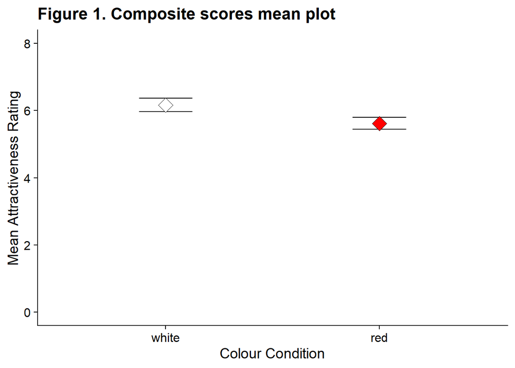

The general equation for the linear model: outcome = b0 + b1(predictor1) + error. Therefore the linear model for this particular experiment is: attractiveness rating = 6.16 + -0.55(colour) + error.

# Discussion

From this experiment and the statistical analysis, it is clear that a significant result was produced. The difference between the mean attractiveness ratings for both the red and white condition were larger than we would expect to find if the null hypothesis were true. The study showed that there was a difference in perceived attractiveness ratings for those who viewed the red photo compared to those who viewed the white photo and overall the white control condition gave a higher mean attractiveness rating compared to the red experimental group.

This study was a replication of Elliot et al (2010) yet contributes conflicting evidence to the area of interest. Using the same design as the study above, Elliot et al (2010) found red significantly influenced women’s attraction to men; participants in the red condition, compared to those in the white condition rated the target male as more attractive, supporting their hypothesis that colour influences participants ratings without their awareness. However, this study showed that an opposite pattern of results can be produced, with participants in the white condition giving higher attractiveness ratings. This suggests the ‘red effect’ may not be as important as Elliot suggested and it is possible for this effect to be falsified.

There has been a variety of different outcomes of studies testing a similar or the same hypothesis. For example, in support of Elliot et al (2010) and in contrast to this study, Elliot and Niesta (2008) found that when men had to rate the attractiveness of women on either a red or white background, those that viewed the red percieved women as more attractive and sexually desirable. Similarly, Young (2015) also found that when pre-rated attractive and unattractive female faces were placed on either a red or grey background, red enhanced the male’s ratings of female attractiveness for those already considered attractive. Both of these studies supported Elliot’s colour in context theory that suggested colours can carry specific meanings, that can affect human cognition and the way we view things i.e. red being associated with physical attractiveness. However, Francis (2013) implied that many of the studies in support of this theory were often a result of publication bias, due to either poor experimental design or experiments where the null hypothesis was supported were not reported. Some studies however showed that the red effect did not occur, similar to the study above, for example, Hesslinger and Goldbach (2015) replicated Elliot’s study and found no significant colour effect on perceived attractiveness for both their original mixed gender sample and a female only sample. Similarly to our study, Peperkoorn, Roberts and Pollet (2016) did not find the predicted red effect, but instead found that participants in the white condition rated women as more attractive compared to those in the red. While there are some studies to suggest the red effect is unlikely to occur, there is still uncertainty about the effect the colour red could have on perceived attractiveness ratings. Therefore, in order to understand this effect fully, there needs to be more experiments to help falsify the claim, that ensure all results are published, regardless of being supporting or contradicting.

Taking into account the studies mentioned above and the study conducted here, there is a suggestion that it is unlikely that red would enhance the perceived attractiveness of men. Both replications of Elliot et al (2010) original study found contradicting effects; this study found that those In the white control condition perceived men as more attractive, while another found no significant differences between the two conditions (Hesslinger and Goldbach, 2015), implying that the red effect can be falsified. Along with this, Francis (2013) highlighted the publication bias within this area of research. Due to the novel and unique nature of the research question, results supporting the hypothesis are more likely to be published regardless of poor methodology or small samples. Suggesting the ‘red effect’ may not be as significant as it seems. However, because this effect is in its infancy, it Is still worth investigating further. Future studies should focus on general human associations made to the colour red and testing the red effect on larger samples for both males and females, including different sexualities.

In conclusion, it is clear from this study that the red effect did not occur, with those in the white control condition rating men as more physically attractive compared to those in the experimental red condition. This area of interest has been subject to publication bias, suggesting that in order to fully falsify the red effect, further research needs to be carried out on a large scale with all results being published. The question of whether red has an effect on perceived physical attractiveness remains, with the associations and meanings behind the colour red needed more in-depth investigating.

# References

Elliot, A. J., & Niesta, D. (2008). Romantic red: Red enhances men’s attraction to women. Journal of personality and social psychology, 95(5), 1150.

Elliot, A. J., Niesta Kayser, D., Greitemeyer, T., Lichtenfeld, S., Gramzow, R. H., Maier, M. A., & Liu, H. (2010). Red, rank, and romance in women viewing men. Journal of Experimental Psychology: General, 139(3), 399.

Francis, G. (2013). Publication bias in “Red, rank, and romance in women viewing men,” by elliot et al. (2010). Journal of Experimental Psychology: General, 142(1), 292-296. doi:http://dx.doi.org/10.1037/a0027923

Hesslinger, V. M., Goldbach, L., & Carbon, C. C. (2015). Men in red: A reexamination of the red-attractiveness effect. Psychonomic bulletin & review, 22(4), 1142-1148.

Peperkoorn, L. S., Roberts, S. C., & Pollet, T. V. (2016). Revisiting the red effect on attractiveness and sexual receptivity: No effect of the color red on human mate preferences. Evolutionary Psychology, 14(4), 1474704916673841.

Young, S. G. (2015). The effect of red on male perceptions of female attractiveness: Moderation by baseline attractiveness of female faces. European Journal of Social Psychology, 45(2), 146-151.